# Exercise solutions: Section 8.8

# fpp3 8.8, Ex11

> For this exercise use the quarterly number of arrivals to Australia from New Zealand, 1981 Q1 – 2012 Q3, from data set `aus_arrivals`.
> 1. Make a time plot of your data and describe the main features of the series.

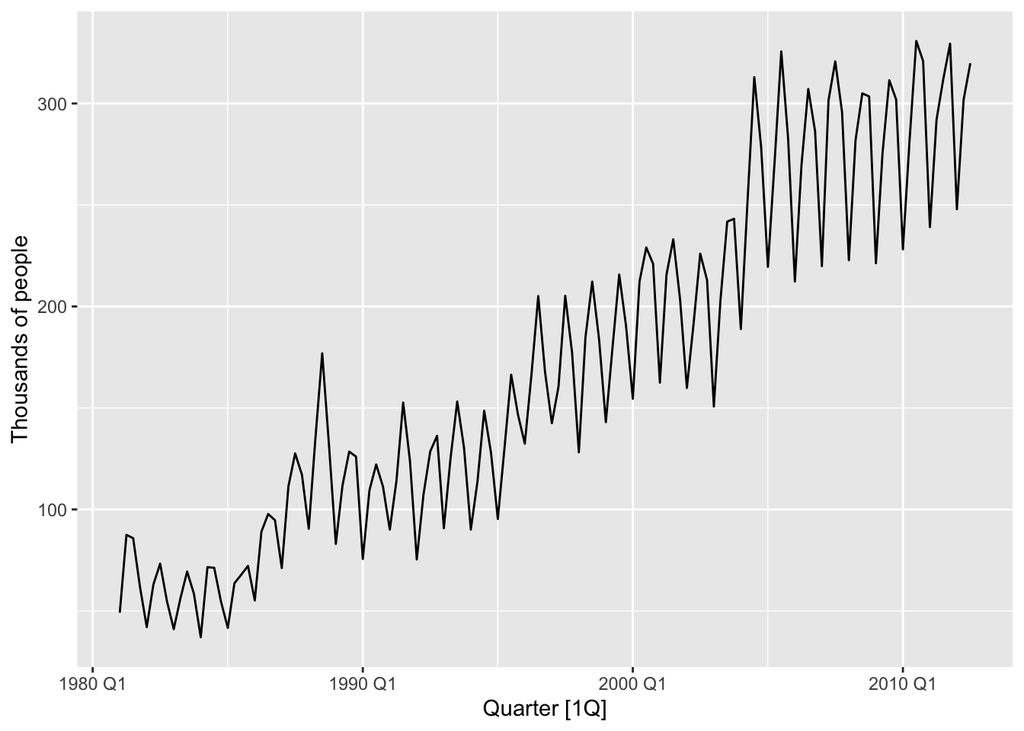

```r
nzarrivals <- aus_arrivals |> filter(Origin == "NZ")
nzarrivals |> autoplot(Arrivals / 1e3) + labs(y = "Thousands of people")
```

- The data has an upward trend.
- The data has a seasonal pattern which increases in size approximately proportionally to the average number of people who arrive per year. Therefore, the data has multiplicative seasonality.
> 2. Create a training set that withholds the last two years of available data. Forecast the test set using an appropriate model for Holt-Winters’ multiplicative method.

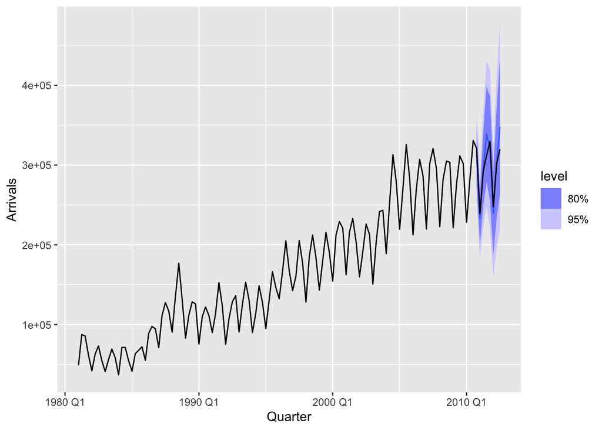

```r
nz_tr <- nzarrivals |>
  slice(1:(n() - 8))
nz_tr |>
  model(ETS(Arrivals ~ error("M") + trend("A") + season("M"))) |>
  forecast(h = "2 years") |>
  autoplot() +
  autolayer(nzarrivals, Arrivals)
```

> 3. Why is multiplicative seasonality necessary here?
- The multiplicative seasonality is important in this example because the seasonal pattern increases in size proportionally to the level of the series.
- The behaviour of the seasonal pattern will be captured and projected in a model with multiplicative seasonality.
> 4. Forecast the two-year test set using each of the following methods:
>    1. an ETS model;
>    2. an additive ETS model applied to a log transformed series;
>    3. a seasonal naïve method;
>    4. an STL decomposition applied to the log transformed data followed by an ETS model applied to the seasonally adjusted (transformed) data.

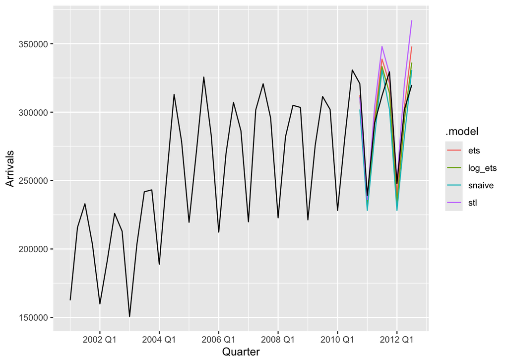

```r
fc <- nz_tr |>
  model(
    ets = ETS(Arrivals),
    log_ets = ETS(log(Arrivals)),
    snaive = SNAIVE(Arrivals),
    stl = decomposition_model(STL(log(Arrivals)), ETS(season_adjust))
  ) |>
  forecast(h = "2 years")

fc |>
  autoplot(level = NULL) +
  autolayer(filter(nzarrivals, year(Quarter) > 2000), Arrivals)
```

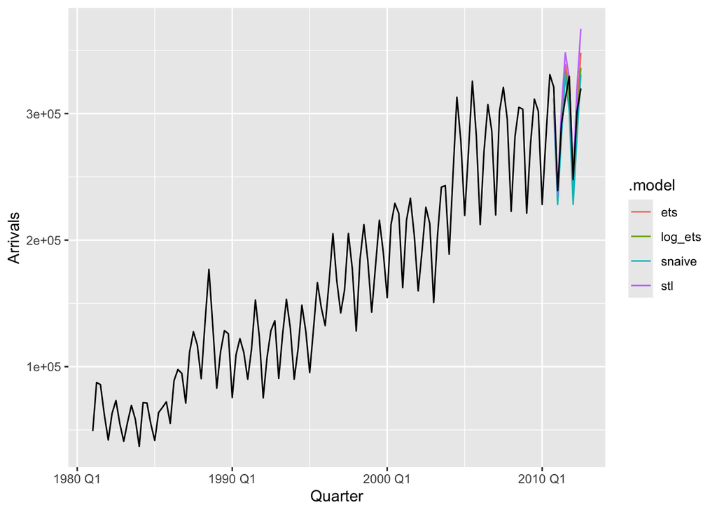

```r
fc |>
  autoplot(level = NULL) +
  autolayer(nzarrivals, Arrivals)
```

> 5. Which method gives the best forecasts? Does it pass the residual tests?

```r
fc |>
  accuracy(nzarrivals)
```

```
# A tibble: 4 × 11
  .model  Origin .type      ME   RMSE    MAE    MPE  MAPE  MASE RMSSE    ACF1
  <chr>   <chr>  <chr>   <dbl>  <dbl>  <dbl>  <dbl> <dbl> <dbl> <dbl>   <dbl>
1 ets     NZ     Test   -3495. 14913. 11421. -0.964  3.78 0.768 0.771 -0.0260
2 log_ets NZ     Test    2467. 13342. 11904.  1.03   4.03 0.800 0.689 -0.0786
3 snaive  NZ     Test    9709. 18051. 17156.  3.44   5.80 1.15  0.933 -0.239
4 stl     NZ     Test  -12535. 22723. 16172. -4.02   5.23 1.09  1.17   0.109
```

- The best method is the ETS model on the logged data (based on RMSE), and it passes the residuals tests.

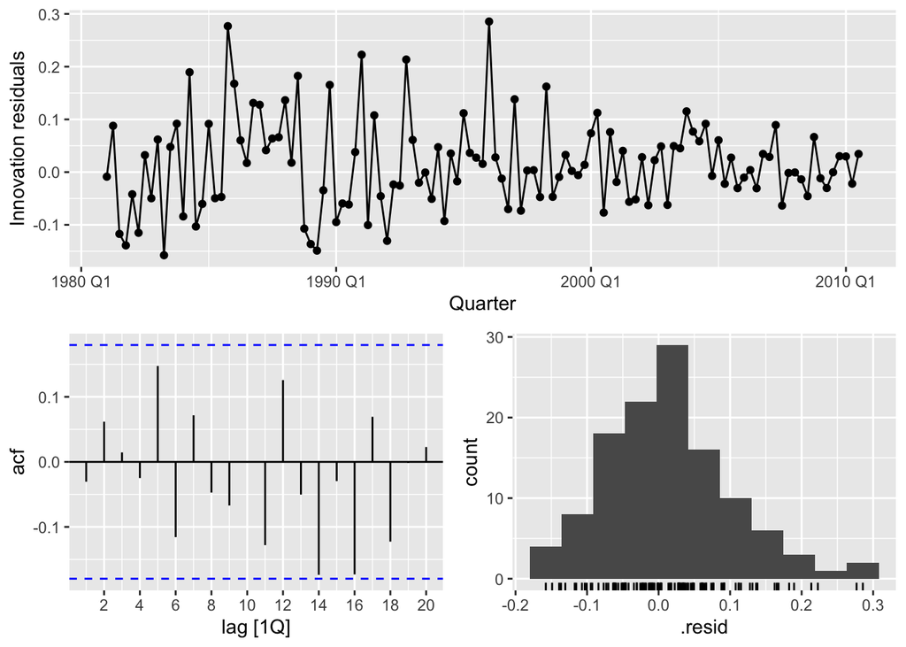

```r
log_ets <- nz_tr |>
  model(ETS(log(Arrivals)))
log_ets |> gg_tsresiduals()
```

```r
augment(log_ets) |>
  features(.innov, ljung_box, lag = 12)
```

```
# A tibble: 1 × 4
  Origin .model             lb_stat lb_pvalue
  <chr>  <chr>                <dbl>     <dbl>
1 NZ     ETS(log(Arrivals))    11.0     0.530
```

> 6. Compare the same four methods using time series cross-validation instead of using a training and test set. Do you come to the same conclusions?

```r
nz_cv <- nzarrivals |>
  slice(1:(n() - 3)) |>
  stretch_tsibble(.init = 36, .step = 3)

nz_cv |>
  model(
    ets = ETS(Arrivals),
    log_ets = ETS(log(Arrivals)),
    snaive = SNAIVE(Arrivals),
    stl = decomposition_model(STL(log(Arrivals)), ETS(season_adjust))
  ) |>
  forecast(h = 3) |>
  accuracy(nzarrivals)
```

```
# A tibble: 4 × 11
  .model  Origin .type    ME   RMSE    MAE   MPE  MAPE  MASE RMSSE  ACF1
  <chr>   <chr>  <chr> <dbl>  <dbl>  <dbl> <dbl> <dbl> <dbl> <dbl> <dbl>
1 ets     NZ     Test  4627. 15327. 11799.  2.23  6.45 0.793 0.797 0.283
2 log_ets NZ     Test  4388. 15047. 11566.  1.99  6.36 0.778 0.782 0.268
3 snaive  NZ     Test  8244. 18768. 14422.  3.83  7.76 0.970 0.976 0.566
4 stl     NZ     Test  4252. 15618. 11873.  2.04  6.25 0.798 0.812 0.244
```

- An initial fold size (`.init`) of 36 has been selected to ensure that sufficient data is available to make reasonable forecasts.
- A step size of 3 (and forecast horizon of 3) has been used to reduce the computation time.
- The ETS model on the log data still appears best (based on 3-step ahead forecast RMSE).

# fpp3 8.8, Ex14

> 1. Use `ETS()` to select an appropriate model for the following series: total number of trips across Australia using `tourism`, the closing prices for the four stocks in `gafa_stock`, and the lynx series in `pelt`. Does it always give good forecasts?

### tourism

```r
aus_trips <- tourism |>
  summarise(Trips = sum(Trips))
aus_trips |>
  model(ETS(Trips)) |>
  report()
```

```
Series: Trips
Model: ETS(A,A,A)
  Smoothing parameters:
    alpha = 0.4495675
    beta  = 0.04450178
    gamma = 0.0001000075

  Initial states:
     l[0]      b[0]      s[0]     s[-1]     s[-2]    s[-3]
 21689.64 -58.46946 -125.8548 -816.3416 -324.5553 1266.752

  sigma^2:  699901.4

     AIC     AICc      BIC
1436.829 1439.400 1458.267
```

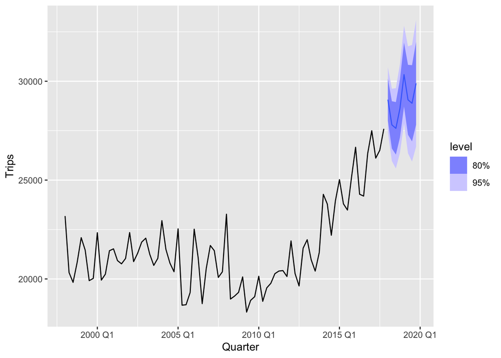

```r
aus_trips |>
  model(ETS(Trips)) |>
  forecast() |>
  autoplot(aus_trips)
```

Forecasts appear reasonable.

### GAFA stock

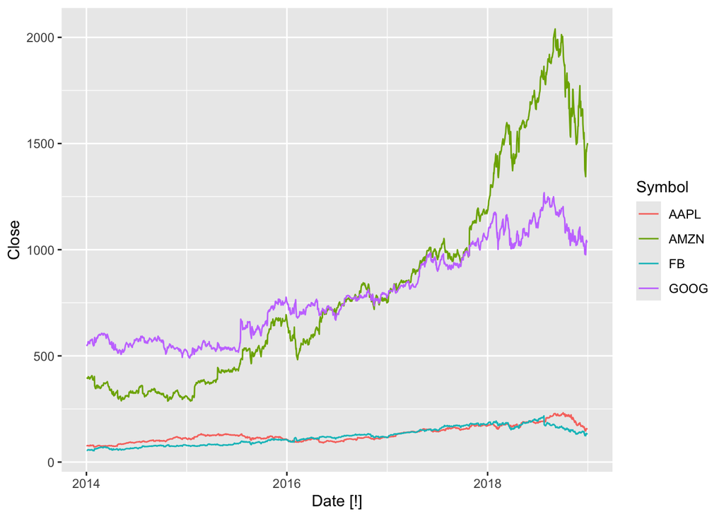

```r
gafa_regular <- gafa_stock |>
  group_by(Symbol) |>
  mutate(trading_day = row_number()) |>
  ungroup() |>
  as_tsibble(index = trading_day, regular = TRUE)

gafa_stock |> autoplot(Close)
```

```r
gafa_regular |>
  model(ETS(Close))
```

```
# A mable: 4 x 2
# Key:     Symbol [4]
  Symbol `ETS(Close)`
  <chr>       <model>
1 AAPL   <ETS(M,N,N)>
2 AMZN   <ETS(M,N,N)>
3 FB     <ETS(M,N,N)>
4 GOOG   <ETS(M,N,N)>
```

```
`mutate_if()` ignored the following grouping variables:
• Column `Symbol`
```

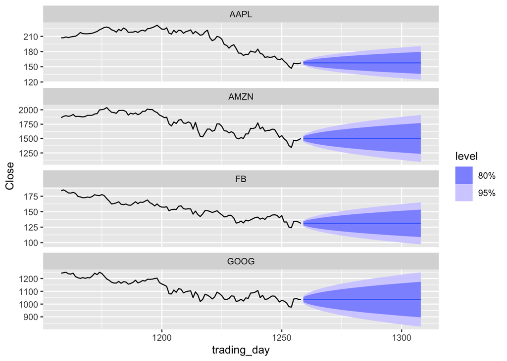

```r
gafa_regular |>
  model(ETS(Close)) |>
  forecast(h = 50) |>
  autoplot(gafa_regular |> group_by_key() |> slice((n() - 100):n()))
```

Forecasts look reasonable for an efficient market.

### Pelt trading records

```r
pelt |>
  model(ETS(Lynx))
```

```
# A mable: 1 x 1
   `ETS(Lynx)`
       <model>
1 <ETS(A,N,N)>
```

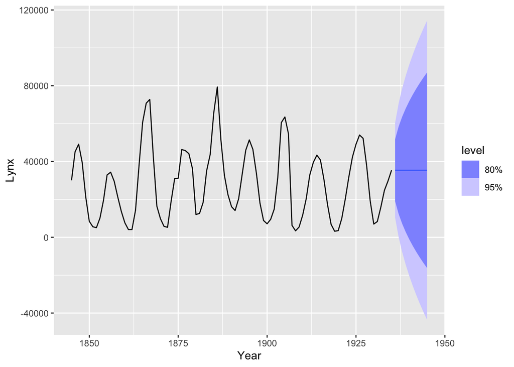

```r
pelt |>
  model(ETS(Lynx)) |>
  forecast(h = 10) |>
  autoplot(pelt)
```

- Here the cyclic behaviour of the lynx data is completely lost.
- ETS models are not designed to handle cyclic data, so there is nothing that can be done to improve this.
> 2. Find an example where it does not work well. Can you figure out why?
- ETS does not work well on cyclic data, as seen in the pelt dataset above.